[figure not shown]

[interactive chart not shown]

3 de outubro → 3 de novembro

# Um mês

O Niko tem uma entrega pra você. Aperta o play e segue o fio.

Oiii, minha princesa! ❤️

Talvez você tenha percebido que hoje é dia 3 de novembro, e isso significa que completamos um mês desde o dia em que nos conhecemos pessoalmente pela primeira vez e demos o nosso primeiro beijo. Um mês desde aquela noite que, por mais que o tempo passe, tenho certeza de que vou guardar com muito carinho na minha memória.

Você estava tão linda, tão cheirosa, que, quando te vi, fiquei em transe por alguns segundos, simplesmente admirando você. Acho que, naquele momento, meu coração estava tão encantado que até esqueceu como agir normalmente. E, se eu pudesse voltar no tempo, viveria cada segundo daquela noite novamente, sem mudar absolutamente nada.

Eu acredito que ainda vamos viver muitos dias especiais juntos, conhecer lugares, colecionar momentos, dar muitos outros beijos e construir lembranças que um dia vamos recordar com aquele sorriso bobo no rosto. Mas, independentemente de tudo que ainda está por vir, nunca vou esquecer o nosso primeiro encontro. Afinal, foi naquela noite que senti Deus falar comigo de uma maneira que somente o meu coração seria capaz de entender.

Por muito tempo, orei e pedi a Ele que colocasse alguém especial na minha vida. Talvez eu ainda não tivesse recebido a resposta que tanto esperava porque simplesmente não era o momento certo. Mas, naquela noite do dia 3 de outubro, tive a sensação de que todas aquelas orações finalmente estavam sendo respondidas. E sabe o que é mais bonito? É perceber que a resposta veio de uma forma muito mais especial do que eu poderia imaginar: veio através de você.

Desde então, você tem se tornado uma das partes mais bonitas dos meus dias. É incrível como uma simples mensagem sua, um carinho, um áudio ou até mesmo você me chamando de meu bem ou meu amor consegue mudar completamente o meu humor. Às vezes, posso estar tendo um dia difícil, com a cabeça cheia e preocupado com mil coisas, mas basta lembrar que tenho você na minha vida para tudo parecer um pouquinho mais leve. Seu amor tem esse efeito em mim, minha princesa. Você consegue melhorar meus dias sem nem perceber, simplesmente sendo você.

meu bem meu amor

Quero que você saiba que sou muito feliz por ter encontrado você e, principalmente, por poder conhecer cada vez mais essa menina maravilhosa que existe por trás desse sorriso tão lindo. Admiro seu jeitinho, seu carinho, sua maneira de falar comigo e cada pequeno detalhe que faz de você alguém tão especial para mim.

Sei que ainda estamos no comecinho da nossa história, mas quero aproveitar cada pedacinho dela ao seu lado. Não tenho pressa para viver tudo de uma vez, porque o que mais quero é ter a oportunidade de construir algo bonito com você, um dia de cada vez, com muito amor, respeito, cuidado e carinho.

Obrigado por ter chegado à minha vida e por fazer meu coração tão feliz. Se há um mês você já era a menina que me deixou completamente encantado naquela noite, hoje é a menina que faz meus dias serem melhores só por existir.

Feliz nosso primeiro mês desde aquele dia tão especial, minha princesa! Que esse seja apenas o primeiro de muitos meses, muitos encontros, muitos beijos e muitas histórias que ainda vamos viver juntos.

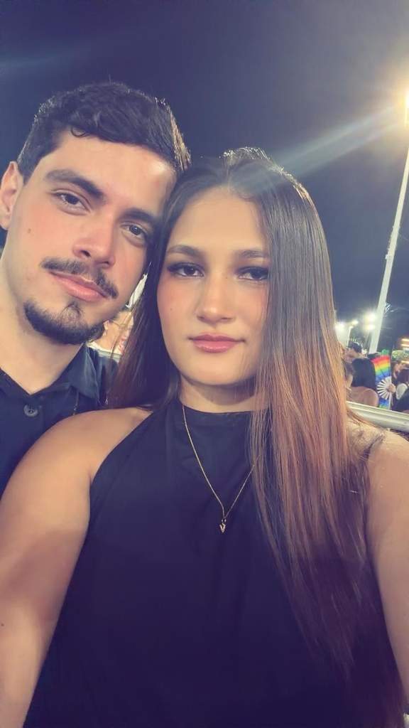

Nossa primeira foto juntos

Eu gosto de você mais do que consigo colocar em palavras. E espero conseguir demonstrar isso todos os dias, não apenas com palavras bonitas, mas principalmente com minhas atitudes.

Te amo, minha princesa! ❤️

Entrega feita. Ele aceita carinho extra.